# **Predicting Breast Cancer Diagnosis**

**## Step 1: Understanding the Problem**

🎯 **Objective**

Predict whether a tumor is:

> Malignant (M)

> Benign (B)

using cell nucleus measurements.

**## Step 2: Loading the Necessary Libraries**

```python
import pandas as pd
import numpy as np
import matplotlib.pyplot as plt
import seaborn as sns
from sklearn.model_selection import train_test_split
from sklearn.preprocessing import StandardScaler
from sklearn.metrics import accuracy_score, classification_report, confusion_matrix
from sklearn.linear_model import LogisticRegression
from sklearn.tree import DecisionTreeClassifier
from sklearn.ensemble import RandomForestClassifier
from sklearn.svm import SVC

print("Libraries loaded successfully!")
```

```
Libraries loaded successfully!
```

**## Step 3: Loading & Reading the Data**

```python
bc_source = 'https://raw.githubusercontent.com/HackBio-Internship/2025_project_collection/refs/heads/main/Python/Dataset/data-3.csv'
```

```python
df = pd.read_csv(bc_source)
print("Dataset loaded successfully. First 5 rows:")
print(df.head())
```

```
Dataset loaded successfully. First 5 rows:
         id diagnosis  radius_mean  texture_mean  perimeter_mean  area_mean  \
0    842302         M        17.99         10.38          122.80     1001.0
1    842517         M        20.57         17.77          132.90     1326.0
2  84300903         M        19.69         21.25          130.00     1203.0
3  84348301         M        11.42         20.38           77.58      386.1
4  84358402         M        20.29         14.34          135.10     1297.0

   smoothness_mean  compactness_mean  concavity_mean  concave points_mean  \
0          0.11840           0.27760          0.3001              0.14710
1          0.08474           0.07864          0.0869              0.07017
2          0.10960           0.15990          0.1974              0.12790
3          0.14250           0.28390          0.2414              0.10520
4          0.10030           0.13280          0.1980              0.10430

```

[output cut: 22 more lines]

**## Step 4: Initial Data Exploration**

```python
print("Dataset Information:")
df.info()
print("\nDataset Shape:", df.shape)
```

```
Dataset Information:
<class 'pandas.core.frame.DataFrame'>
RangeIndex: 569 entries, 0 to 568
Data columns (total 33 columns):
 #   Column                   Non-Null Count  Dtype
---  ------                   --------------  -----
 0   id                       569 non-null    int64
 1   diagnosis                569 non-null    object
 2   radius_mean              569 non-null    float64
 3   texture_mean             569 non-null    float64
 4   perimeter_mean           569 non-null    float64
 5   area_mean                569 non-null    float64
 6   smoothness_mean          569 non-null    float64
 7   compactness_mean         569 non-null    float64
 8   concavity_mean           569 non-null    float64
```

[output cut: 28 more lines]

```python
df.head()
```

|  | id | diagnosis | radius_mean | texture_mean | perimeter_mean | area_mean | smoothness_mean | compactness_mean | concavity_mean | concave points_mean | ... | texture_worst | perimeter_worst | area_worst | smoothness_worst | compactness_worst | concavity_worst | concave points_worst | symmetry_worst | fractal_dimension_worst | Unnamed: 32 |
| --- | --- | --- | --- | --- | --- | --- | --- | --- | --- | --- | --- | --- | --- | --- | --- | --- | --- | --- | --- | --- | --- |
| 0 | 842302 | M | 17.99 | 10.38 | 122.80 | 1001.0 | 0.11840 | 0.27760 | 0.3001 | 0.14710 | ... | 17.33 | 184.60 | 2019.0 | 0.1622 | 0.6656 | 0.7119 | 0.2654 | 0.4601 | 0.11890 | NaN |
| 1 | 842517 | M | 20.57 | 17.77 | 132.90 | 1326.0 | 0.08474 | 0.07864 | 0.0869 | 0.07017 | ... | 23.41 | 158.80 | 1956.0 | 0.1238 | 0.1866 | 0.2416 | 0.1860 | 0.2750 | 0.08902 | NaN |
| 2 | 84300903 | M | 19.69 | 21.25 | 130.00 | 1203.0 | 0.10960 | 0.15990 | 0.1974 | 0.12790 | ... | 25.53 | 152.50 | 1709.0 | 0.1444 | 0.4245 | 0.4504 | 0.2430 | 0.3613 | 0.08758 | NaN |
| 3 | 84348301 | M | 11.42 | 20.38 | 77.58 | 386.1 | 0.14250 | 0.28390 | 0.2414 | 0.10520 | ... | 26.50 | 98.87 | 567.7 | 0.2098 | 0.8663 | 0.6869 | 0.2575 | 0.6638 | 0.17300 | NaN |
| 4 | 84358402 | M | 20.29 | 14.34 | 135.10 | 1297.0 | 0.10030 | 0.13280 | 0.1980 | 0.10430 | ... | 16.67 | 152.20 | 1575.0 | 0.1374 | 0.2050 | 0.4000 | 0.1625 | 0.2364 | 0.07678 | NaN |

5 rows × 33 columns

**## Step 5: Data Cleaning and Preprocessing**

```python
# Drop 'id' column as it is not relevant for prediction and 'Unnamed: 32' which is empty
df.drop(['id', 'Unnamed: 32'], axis=1, inplace=True)

# Encode the 'diagnosis' column (M = Malignant, B = Benign)
# M will be 1, B will be 0
df['diagnosis'] = df['diagnosis'].map({'M': 1, 'B': 0})

print("Columns dropped and 'diagnosis' column encoded. First 5 rows:")
print(df.head())
```

```
Columns dropped and 'diagnosis' column encoded. First 5 rows:
   diagnosis  radius_mean  texture_mean  perimeter_mean  area_mean  \
0          1        17.99         10.38          122.80     1001.0
1          1        20.57         17.77          132.90     1326.0
2          1        19.69         21.25          130.00     1203.0
3          1        11.42         20.38           77.58      386.1
4          1        20.29         14.34          135.10     1297.0

   smoothness_mean  compactness_mean  concavity_mean  concave points_mean  \
0          0.11840           0.27760          0.3001              0.14710
1          0.08474           0.07864          0.0869              0.07017
2          0.10960           0.15990          0.1974              0.12790
3          0.14250           0.28390          0.2414              0.10520
4          0.10030           0.13280          0.1980              0.10430

```

[output cut: 22 more lines]

**## Step 6: Splitting the Data into Training and Testing Sets**

```python
# Separate features (X) and target (y)
# Explicitly drop 'id' and 'Unnamed: 32' columns, even if they were meant to be dropped earlier,
# to ensure X does not contain them. 'errors='ignore'' will prevent an error if they are already absent.
X = df.drop(['diagnosis', 'id', 'Unnamed: 32'], axis=1, errors='ignore')
y = df['diagnosis']

print("Features (X) shape:", X.shape)
print("Target (y) shape:", y.shape)
```

```
Features (X) shape: (569, 30)
Target (y) shape: (569,)
```

```python
# Split the data into training, validation, and testing sets
# First, split off the test set (10%)
X_train_val, X_test, y_train_val, y_test = train_test_split(X, y, test_size=0.1, random_state=42, stratify=y)

# Then, split the remaining data (X_train_val, y_train_val is now 90% of original)
# into training (70% of original) and validation (20% of original).
# The test_size for this second split should be (0.2 / 0.9) to get 20% validation from the original data.
X_train, X_val, y_train, y_val = train_test_split(X_train_val, y_train_val, test_size=(0.2/0.9), random_state=42, stratify=y_train_val)

print("X_train shape:", X_train.shape)
print("X_val shape:", X_val.shape)
print("X_test shape:", X_test.shape)
print("y_train shape:", y_train.shape)
print("y_val shape:", y_val.shape)
print("y_test shape:", y_test.shape)
```

```
X_train shape: (398, 30)
X_val shape: (114, 30)
X_test shape: (57, 30)
y_train shape: (398,)
y_val shape: (114,)
y_test shape: (57,)
```

**### Target Variable Distribution**

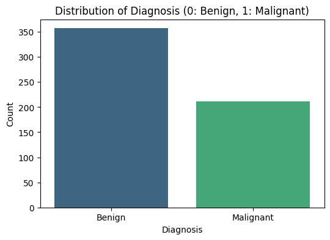

```python
# Visualize the distribution of the target variable
plt.figure(figsize=(6, 4))
sns.countplot(x='diagnosis', data=df, palette='viridis')
plt.title('Distribution of Diagnosis (0: Benign, 1: Malignant)')
plt.xlabel('Diagnosis')
plt.ylabel('Count')
plt.xticks(ticks=[0, 1], labels=['Benign', 'Malignant'])
plt.show()
```

**## Step 7: Feature Scaling**

```python
# Initialize the StandardScaler
scaler = StandardScaler()

# Fit the scaler on the training data and transform it
X_train_scaled = scaler.fit_transform(X_train)

# Transform the validation and test data using the *same* scaler fitted on the training data
X_val_scaled = scaler.transform(X_val)
X_test_scaled = scaler.transform(X_test)

print("Features scaled successfully!")
print("X_train_scaled shape:", X_train_scaled.shape)
print("X_val_scaled shape:", X_val_scaled.shape)
print("X_test_scaled shape:", X_test_scaled.shape)
```

```
Features scaled successfully!
X_train_scaled shape: (398, 30)
X_val_scaled shape: (114, 30)
X_test_scaled shape: (57, 30)
```

**## Step 8: Model Training (Baseline)- Logistic Regression**

```python
# Initialize and train the Logistic Regression model
log_reg_model = LogisticRegression(random_state=42)
log_reg_model.fit(X_train_scaled, y_train)

print("Logistic Regression model trained successfully!")
```

```
Logistic Regression model trained successfully!
```

**### Step 9: Model Evaluation - Logistic Regression**

```
Logistic Regression Model Evaluation on Validation Set:
Accuracy: 0.9912

Classification Report:
              precision    recall  f1-score   support

           0       1.00      0.99      0.99        71
           1       0.98      1.00      0.99        43

    accuracy                           0.99       114
   macro avg       0.99      0.99      0.99       114
weighted avg       0.99      0.99      0.99       114
```

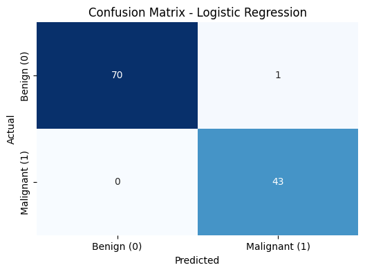

```python
# Predict on the validation set
y_val_pred = log_reg_model.predict(X_val_scaled)

# Calculate evaluation metrics
print("Logistic Regression Model Evaluation on Validation Set:")
print(f"Accuracy: {accuracy_score(y_val, y_val_pred):.4f}")
print("\nClassification Report:")
print(classification_report(y_val, y_val_pred))

# Confusion Matrix
cm = confusion_matrix(y_val, y_val_pred)
plt.figure(figsize=(6, 4))
sns.heatmap(cm, annot=True, fmt='d', cmap='Blues', cbar=False,
            xticklabels=['Benign (0)', 'Malignant (1)'],
            yticklabels=['Benign (0)', 'Malignant (1)'])
plt.xlabel('Predicted')
plt.ylabel('Actual')
plt.title('Confusion Matrix - Logistic Regression')
plt.show()
```

**## Step 10: Feature Selection**

> Feature selection is the process of choosing a subset of relevant features for use in model construction. It can help in several ways:
- **Reducing Overfitting:** By removing irrelevant or redundant features, we can reduce the complexity of the model, making it less likely to overfit the training data.
- **Improving Accuracy:** Sometimes, removing noisy features can lead to a more accurate model.
- **Reducing Training Time:** Fewer features mean less computation, leading to faster training.
- **Enhancing Interpretability:** A simpler model with fewer features is often easier to understand and explain.

> I will start by looking at correlations between features to identify and potentially remove highly correlated ones, as this can cause multicollinearity issues for linear models like Logistic Regression.

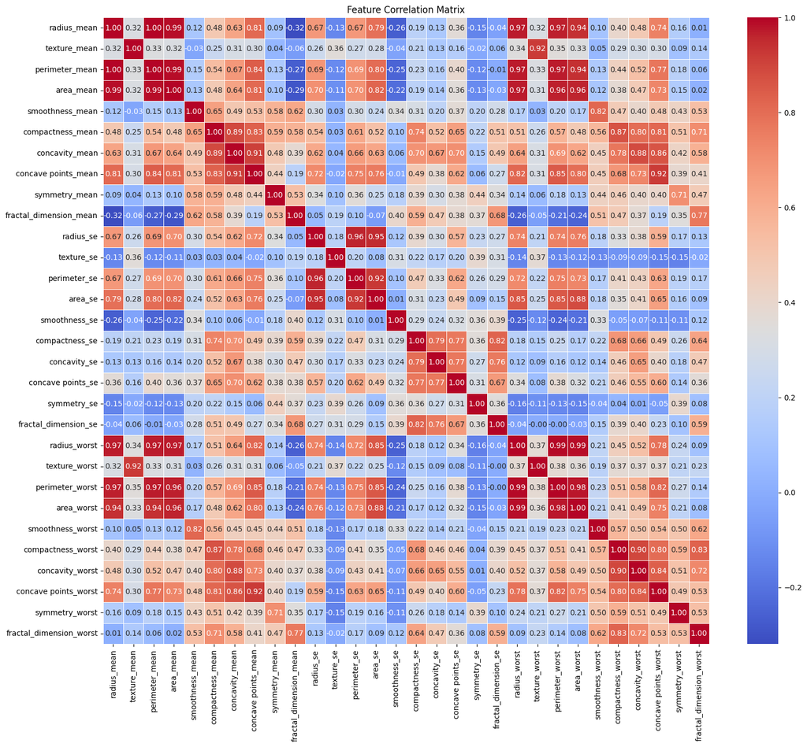

```python
# Calculate the correlation matrix for the features
correlation_matrix = X_train.corr()

# Visualize the correlation matrix
plt.figure(figsize=(18, 15))
sns.heatmap(correlation_matrix, annot=True, cmap='coolwarm', fmt='.2f', linewidths=.5)
plt.title('Feature Correlation Matrix')
plt.show()
```

**### Observations**

> From the correlation matrix, we can observe that many features are highly correlated with each other. High multicollinearity can be an issue for Logistic Regression. I will implement a strategy to remove one of the two features if their correlation is above a certain threshold (e.g., 0.9).

```python
def remove_highly_correlated_features(df, threshold=0.9):
    corr_matrix = df.corr().abs()
    upper_tri = corr_matrix.where(np.triu(np.ones(corr_matrix.shape), k=1).astype(bool))
    to_drop = [column for column in upper_tri.columns if any(upper_tri[column] > threshold)]
    return df.drop(columns=to_drop), to_drop

# Apply the function to our training features
X_train_selected, dropped_features = remove_highly_correlated_features(X_train, threshold=0.9)
print(f"Dropped {len(dropped_features)} highly correlated features: {dropped_features}")

# Get the names of the remaining features
selected_features = X_train_selected.columns

# Apply the same selection to validation and test sets
X_val_selected = X_val[selected_features]
X_test_selected = X_test[selected_features]

print("Shape after feature selection:")
print("X_train_selected shape:", X_train_selected.shape)
print("X_val_selected shape:", X_val_selected.shape)
print("X_test_selected shape:", X_test_selected.shape)
```

```
Dropped 10 highly correlated features: ['perimeter_mean', 'area_mean', 'concave points_mean', 'perimeter_se', 'area_se', 'radius_worst', 'texture_worst', 'perimeter_worst', 'area_worst', 'concave points_worst']
Shape after feature selection:
X_train_selected shape: (398, 20)
X_val_selected shape: (114, 20)
X_test_selected shape: (57, 20)
```

**### Comments**

> Now that I have selected features, I need to re-scale the data using only these selected features and then re-train and re-evaluate our Logistic Regression model.

```python
# Re-initialize and fit the scaler on the selected training data
scaler_selected = StandardScaler()
X_train_scaled_selected = scaler_selected.fit_transform(X_train_selected)

# Transform the selected validation and test data
X_val_scaled_selected = scaler_selected.transform(X_val_selected)
X_test_scaled_selected = scaler_selected.transform(X_test_selected)

print("Features scaled successfully after selection!")
print("X_train_scaled_selected shape:", X_train_scaled_selected.shape)
print("X_val_scaled_selected shape:", X_val_scaled_selected.shape)
print("X_test_scaled_selected shape:", X_test_scaled_selected.shape)
```

```
Features scaled successfully after selection!
X_train_scaled_selected shape: (398, 20)
X_val_scaled_selected shape: (114, 20)
X_test_scaled_selected shape: (57, 20)
```

**## Step 11: Retraining and Re-evaluating the Model with Selected Features**

```python
# Initialize and train the Logistic Regression model with selected features
log_reg_model_selected = LogisticRegression(random_state=42)
log_reg_model_selected.fit(X_train_scaled_selected, y_train)

print("Logistic Regression model with selected features trained successfully!")
```

```
Logistic Regression model with selected features trained successfully!
```

```
Logistic Regression Model Evaluation on Validation Set (Selected Features):
Accuracy: 0.9825

Classification Report:
              precision    recall  f1-score   support

           0       1.00      0.97      0.99        71
           1       0.96      1.00      0.98        43

    accuracy                           0.98       114
   macro avg       0.98      0.99      0.98       114
weighted avg       0.98      0.98      0.98       114
```

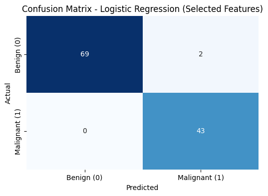

```python
# Predict on the validation set with the new model
y_val_pred_selected = log_reg_model_selected.predict(X_val_scaled_selected)

# Calculate evaluation metrics for the new model
print("Logistic Regression Model Evaluation on Validation Set (Selected Features):")
print(f"Accuracy: {accuracy_score(y_val, y_val_pred_selected):.4f}")
print("\nClassification Report:")
print(classification_report(y_val, y_val_pred_selected))

# Confusion Matrix for the new model
cm_selected = confusion_matrix(y_val, y_val_pred_selected)
plt.figure(figsize=(6, 4))
sns.heatmap(cm_selected, annot=True, fmt='d', cmap='Blues', cbar=False,
            xticklabels=['Benign (0)', 'Malignant (1)'],
            yticklabels=['Benign (0)', 'Malignant (1)'])
plt.xlabel('Predicted')
plt.ylabel('Actual')
plt.title('Confusion Matrix - Logistic Regression (Selected Features)')
plt.show()
```

**## L1 Regularization (Lasso Regression) for Automatic Feature Selection**

L1 Regularization, also known as **Lasso Regression**, is a type of linear regression that adds a penalty equal to the absolute value of the magnitude of the coefficients. This penalty term is added to the loss function that the model tries to minimize during training.

The objective function for L1 regularization looks like this:

$$\text{Minimize: } \sum_{i=1}^{n}(y_i - \hat{y}_i)^2 + \lambda \sum_{j=1}^{p}|\beta_j|$$

Where:

- $n$ is the number of data points.
- $p$ is the number of features.
- $y_i$ is the actual target value for the $i$-th data point.
- $\hat{y}_i$ is the predicted target value for the $i$-th data point.
- $\beta_j$ is the coefficient for the $j$-th feature.
- $\lambda$ (lambda) is the regularization strength parameter ($ \lambda \ge 0 $). It controls how much the coefficients are penalized. A larger $\lambda$ means stronger regularization.

**### How L1 Regularization Achieves Automatic Feature Selection:**

The key characteristic of L1 regularization that makes it perform automatic feature selection is its ability to **drive some feature coefficients exactly to zero**. Here's why:

1. **Absolute Value Penalty:** The penalty term uses the absolute value of the coefficients ($|\beta_j|$). This shape of the penalty function has sharp 'corners' at zero.
2. **Sparsity:** When the optimization algorithm tries to minimize the total loss (original error + L1 penalty), it finds it more efficient to reduce the magnitude of less important coefficients all the way to zero, rather than just making them very small. This results in a sparse model where many coefficients are exactly zero.
3. **Irrelevant Features:** Features with coefficients driven to zero are effectively removed from the model. They no longer contribute to the prediction. This means that L1 regularization automatically selects the most relevant features and discards the irrelevant ones.

**### Advantages**

- **Automatic Feature Selection:** Simplifies the model by reducing the number of features.
- **Improved Interpretability:** Easier to understand the model when fewer features are involved.
- **Reduced Overfitting:** Prevents the model from becoming too complex and fitting noise in the training data.

**### Disadvantages**

- **Tuning Lambda:** The choice of $\lambda$ is crucial and often requires cross-validation.
- **Grouped Variables:** If there are groups of highly correlated features, Lasso tends to pick only one from the group and zeros out the others, which might not always be ideal. (Elastic Net can address this).

> In summary, L1 Regularization is a valuable technique when you suspect that many features might be irrelevant or redundant, and you want the model to automatically identify and prioritize the most important ones.

**## Recursive Feature Elimination (RFE)**

> Recursive Feature Elimination (RFE) is a wrapper-type feature selection method that works by recursively removing features and building a model on the remaining features. It's often used with an estimator that assigns weights to features (e.g., coefficients in linear models, feature importances in tree-based models).

**### How RFE Works**

1. **Initial Model Training:** The RFE algorithm first trains a machine learning model using *all* the available features.
2. **Feature Ranking:** It then ranks the features based on their importance (e.g., coefficients for linear models, feature importances for tree models). Features with smaller absolute coefficients or lower importance scores are considered less significant.
3. **Feature Elimination:** The least important feature(s) are removed from the dataset.
4. **Recursion:** Steps 1-3 are repeated recursively until the desired number of features is reached or a certain criterion (e.g., cross-validation score) is optimized.

**### Key Characteristics**

- **Wrapper Method:** RFE wraps around a specific machine learning model (the estimator). Its performance depends on the chosen estimator.
- **Iterative Process:** It's an iterative process that gradually prunes features.
- **Requires Number of Features:** Typically, you need to specify the desired number of features to select, or use cross-validation to find the optimal number (`RFECV`).

**## L1 Regularization vs. Recursive Feature Elimination**

| Feature | L1 Regularization (Lasso) | Recursive Feature Elimination (RFE) |
| --- | --- | --- |
| **Mechanism** | Adds a penalty to the loss function, shrinking less important feature coefficients to exactly zero. | Iteratively trains a model, ranks features, and removes the least important ones. |
| **Method Type** | Embedded (feature selection is part of the model training process). | Wrapper (uses an external estimator to evaluate feature subsets). |
| **Model Dependence** | Inherently linked to linear models (Logistic Regression, Linear Regression). | Can be used with *any* estimator that provides feature importance or coefficients. |
| **Feature Removal** | Automatic; coefficients become exactly zero. | Explicit; features are removed one by one or in batches based on ranking. |
| **Output** | A model with some coefficients set to zero. | A subset of features identified as the most important. |
| **Computational Cost** | Generally lower than RFE, as it's a single model training process (though hyperparameter tuning can add cost). | Can be computationally more expensive, especially if many features and iterations are involved. |
| **Interpretability** | Results in a sparse model, which is highly interpretable. | Can be interpretable, especially if the underlying estimator is interpretable. |
| **Handling Multicollinearity** | Tends to select one feature from a group of highly correlated features and discard others. | Can be sensitive to multicollinearity if the underlying estimator is. |

**### When to Use Which**

- **L1 Regularization (Lasso):** Ideal when you suspect many features are truly irrelevant, want a sparse and highly interpretable model, and are working with linear models. It's a 'built-in' feature selector.
- **Recursive Feature Elimination (RFE):** Useful when you want to use a specific model (e.g., a tree-based model) for feature selection, need fine-grained control over the number of features, or want to explore different subsets based on model performance. It effectively tells you which features your *chosen model* finds most important.

> Both are valuable tools, and the best choice often depends on the specific dataset, the chosen model, and the goals of the analysis.

**## Step 12: Implementing L1 Regularization (Lasso) for Feature Selection**

```python
from sklearn.linear_model import LogisticRegression
from sklearn.model_selection import GridSearchCV

# Define the Logistic Regression model with L1 penalty
# 'liblinear' solver supports L1 penalty
log_reg_l1 = LogisticRegression(penalty='l1', solver='liblinear', random_state=42)

# Define the parameter grid for C (inverse of regularization strength)
# A smaller C means stronger regularization (more features are zeroed out)
param_grid = {'C': [0.001, 0.01, 0.1, 1, 10, 100]}

# Perform GridSearchCV to find the best C
grid_search_l1 = GridSearchCV(log_reg_l1, param_grid, cv=5, scoring='accuracy', n_jobs=-1)
grid_search_l1.fit(X_train_scaled, y_train)

print(f"Best C parameter: {grid_search_l1.best_params_['C']}")
print(f"Best cross-validation accuracy: {grid_search_l1.best_score_:.4f}")

# Get the best estimator
best_log_reg_l1 = grid_search_l1.best_estimator_
```

```
Best C parameter: 0.1
Best cross-validation accuracy: 0.9699
```

```python
# Extract coefficients from the best L1 Logistic Regression model
# Coeffs for features that are selected will be non-zero
coefficients = best_log_reg_l1.coef_[0]

# Get the names of the original features
feature_names = X.columns

# Create a DataFrame to view feature importance
feature_importance_df = pd.DataFrame({
    'Feature': feature_names,
    'Coefficient': coefficients,
    'Absolute_Coefficient': np.abs(coefficients)
}).sort_values(by='Absolute_Coefficient', ascending=False)

# Identify selected features (those with non-zero coefficients)
selected_features_l1 = feature_importance_df[feature_importance_df['Coefficient'] != 0]['Feature'].tolist()

print(f"Number of features selected by L1 regularization: {len(selected_features_l1)}")
print("Selected Features by L1 Regularization:")
for feature in selected_features_l1:
    print(f"- {feature}")

# Filter X_train, X_val, X_test to include only selected features
X_train_l1 = X_train[selected_features_l1]
X_val_l1 = X_val[selected_features_l1]
X_test_l1 = X_test[selected_features_l1]

print("\nShapes after L1 feature selection:")
print("X_train_l1 shape:", X_train_l1.shape)
print("X_val_l1 shape:", X_val_l1.shape)
print("X_test_l1 shape:", X_test_l1.shape)
```

```
Number of features selected by L1 regularization: 8
Selected Features by L1 Regularization:
- radius_worst
- concave points_worst
- concave points_mean
- texture_worst
- perimeter_worst
- symmetry_worst
- smoothness_worst
- radius_se

Shapes after L1 feature selection:
X_train_l1 shape: (398, 8)
X_val_l1 shape: (114, 8)
X_test_l1 shape: (57, 8)
```

**### Re-scaling and Evaluating with L1 Selected Features**

```
Features scaled successfully after L1 selection!
X_train_scaled_l1 shape: (398, 8)
X_val_scaled_l1 shape: (114, 8)
X_test_scaled_l1 shape: (57, 8)

Logistic Regression Model Evaluation on Validation Set (L1 Selected Features):
Accuracy: 0.9561

Classification Report:
              precision    recall  f1-score   support

           0       0.96      0.97      0.97        71
           1       0.95      0.93      0.94        43

    accuracy                           0.96       114
   macro avg       0.96      0.95      0.95       114
weighted avg       0.96      0.96      0.96       114
```

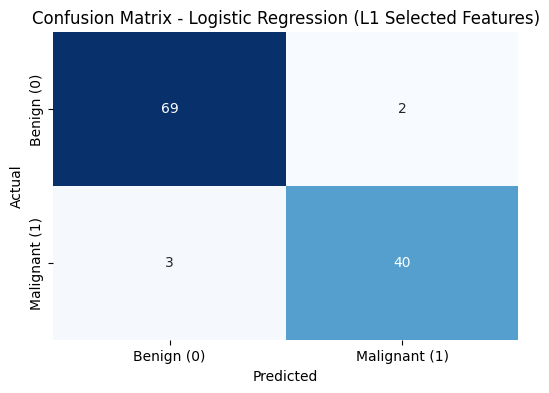

```python
# Re-initialize and fit the scaler on the L1 selected training data
scaler_l1 = StandardScaler()
X_train_scaled_l1 = scaler_l1.fit_transform(X_train_l1)

# Transform the L1 selected validation and test data
X_val_scaled_l1 = scaler_l1.transform(X_val_l1)
X_test_scaled_l1 = scaler_l1.transform(X_test_l1)

print("Features scaled successfully after L1 selection!")
print("X_train_scaled_l1 shape:", X_train_scaled_l1.shape)
print("X_val_scaled_l1 shape:", X_val_scaled_l1.shape)
print("X_test_scaled_l1 shape:", X_test_scaled_l1.shape)

# Train a new Logistic Regression model with the L1 selected features
# Use the best C found by GridSearchCV, but train a fresh model if coefficients are needed
# Or directly use the best_log_reg_l1 model which is already trained on scaled data
log_reg_model_l1 = LogisticRegression(penalty='l1', solver='liblinear', C=grid_search_l1.best_params_['C'], random_state=42)
log_reg_model_l1.fit(X_train_scaled_l1, y_train)

# Predict on the validation set with the new L1 model
y_val_pred_l1 = log_reg_model_l1.predict(X_val_scaled_l1)

# Calculate evaluation metrics for the L1 model
print("\nLogistic Regression Model Evaluation on Validation Set (L1 Selected Features):")
print(f"Accuracy: {accuracy_score(y_val, y_val_pred_l1):.4f}")
print("\nClassification Report:")
print(classification_report(y_val, y_val_pred_l1))

# Confusion Matrix for the L1 model
cm_l1 = confusion_matrix(y_val, y_val_pred_l1)
plt.figure(figsize=(6, 4))
sns.heatmap(cm_l1, annot=True, fmt='d', cmap='Blues', cbar=False,
            xticklabels=['Benign (0)', 'Malignant (1)'],
            yticklabels=['Benign (0)', 'Malignant (1)'])
plt.xlabel('Predicted')
plt.ylabel('Actual')
plt.title('Confusion Matrix - Logistic Regression (L1 Selected Features)')
plt.show()
```

**### Observations**

> Optimal Regularization: GridSearchCV identified C=0.1 as the best regularization parameter. A smaller C value implies stronger regularization, which is why it led to significant feature reduction.

> Feature Selection: L1 regularization successfully reduced the number of features from 30 down to 8. The selected features are: radius_worst, concave points_worst, concave points_mean, texture_worst, perimeter_worst, symmetry_worst, smoothness_worst, and radius_se.

> Model Performance: After re-scaling and training a Logistic Regression model with these 8 selected features, the performance on the validation set is: Accuracy: 0.9561 Classification Report: Class 0 (Benign): Precision: 0.96, Recall: 0.97, F1-score: 0.97 Class 1 (Malignant): Precision: 0.95, Recall: 0.93, F1-score: 0.94

> Compared to the previous Logistic Regression model using all features (Accuracy: 0.9912) and the model after correlation-based feature selection (Accuracy: 0.9825 with 20 features), the L1 regularization model achieves significant dimensionality reduction at the cost of a slight decrease in overall accuracy. Specifically, the recall for the malignant class (Class 1) has dropped from 1.00 to 0.93, indicating that this model is now missing some malignant cases (3 false negatives, as seen in the confusion matrix). This is a trade-off between model simplicity/interpretability and predictive power.

**## Step 13: Implementing Recursive Feature Elimination (RFE) for Feature Selection**

```python
from sklearn.feature_selection import RFECV
from sklearn.model_selection import StratifiedKFold

# Initialize the Logistic Regression estimator
# Use 'liblinear' solver for L1 regularization (if preferred) or default for L2
estimator = LogisticRegression(random_state=42, solver='liblinear')

# Initialize RFECV with the estimator, using stratified k-fold for cross-validation
# The scoring parameter should align with the problem type (e.g., 'accuracy' or 'f1_weighted' for classification)
rfecv = RFECV(estimator=estimator, step=1, cv=StratifiedKFold(5), scoring='accuracy', n_jobs=-1)
rfecv.fit(X_train_scaled, y_train)

print(f"Optimal number of features: {rfecv.n_features_}")
print(f"Selected features mask: {rfecv.support_}")

# Get the names of the selected features
selected_features_rfe = X.columns[rfecv.support_].tolist()
print("Selected Features by RFE:")
for feature in selected_features_rfe:
    print(f"- {feature}")

# Filter X_train, X_val, X_test to include only RFE selected features
X_train_rfe = X_train[selected_features_rfe]
X_val_rfe = X_val[selected_features_rfe]
X_test_rfe = X_test[selected_features_rfe]

print("\nShapes after RFE feature selection:")
print("X_train_rfe shape:", X_train_rfe.shape)
print("X_val_rfe shape:", X_val_rfe.shape)
print("X_test_rfe shape:", X_test_rfe.shape)
```

```
Optimal number of features: 22
Selected features mask: [False  True  True  True False  True  True  True False False  True  True
  True  True  True  True False False  True  True  True  True  True  True
  True False  True  True  True False]
Selected Features by RFE:
- texture_mean
- perimeter_mean
- area_mean
- compactness_mean
- concavity_mean
- concave points_mean
- radius_se
- texture_se
- perimeter_se
- area_se
- smoothness_se
- compactness_se
- symmetry_se
- fractal_dimension_se
- radius_worst
- texture_worst
- perimeter_worst
- area_worst
- smoothness_worst
- concavity_worst
- concave points_worst
- symmetry_worst

Shapes after RFE feature selection:
X_train_rfe shape: (398, 22)
X_val_rfe shape: (114, 22)
X_test_rfe shape: (57, 22)
```

**### Re-scaling and Evaluating with RFE Selected Features**

```
Features scaled successfully after RFE selection!
X_train_scaled_rfe shape: (398, 22)
X_val_scaled_rfe shape: (114, 22)
X_test_scaled_rfe shape: (57, 22)

Logistic Regression Model Evaluation on Validation Set (RFE Selected Features):
Accuracy: 0.9912

Classification Report:
              precision    recall  f1-score   support

           0       1.00      0.99      0.99        71
           1       0.98      1.00      0.99        43

    accuracy                           0.99       114
   macro avg       0.99      0.99      0.99       114
weighted avg       0.99      0.99      0.99       114
```

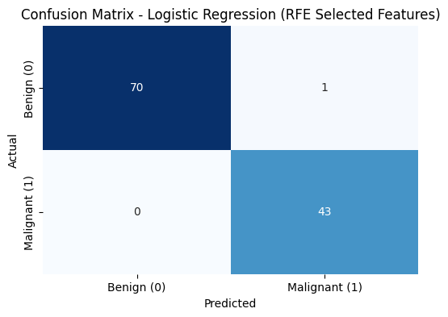

```python
# Re-initialize and fit the scaler on the RFE selected training data
scaler_rfe = StandardScaler()
X_train_scaled_rfe = scaler_rfe.fit_transform(X_train_rfe)

# Transform the RFE selected validation and test data
X_val_scaled_rfe = scaler_rfe.transform(X_val_rfe)
X_test_scaled_rfe = scaler_rfe.transform(X_test_rfe)

print("Features scaled successfully after RFE selection!")
print("X_train_scaled_rfe shape:", X_train_scaled_rfe.shape)
print("X_val_scaled_rfe shape:", X_val_scaled_rfe.shape)
print("X_test_scaled_rfe shape:", X_test_scaled_rfe.shape)

# Train a new Logistic Regression model with the RFE selected features
log_reg_model_rfe = LogisticRegression(random_state=42)
log_reg_model_rfe.fit(X_train_scaled_rfe, y_train)

# Predict on the validation set with the new RFE model
y_val_pred_rfe = log_reg_model_rfe.predict(X_val_scaled_rfe)

# Calculate evaluation metrics for the RFE model
print("\nLogistic Regression Model Evaluation on Validation Set (RFE Selected Features):")
print(f"Accuracy: {accuracy_score(y_val, y_val_pred_rfe):.4f}")
print("\nClassification Report:")
print(classification_report(y_val, y_val_pred_rfe))

# Confusion Matrix for the RFE model
cm_rfe = confusion_matrix(y_val, y_val_pred_rfe)
plt.figure(figsize=(6, 4))
sns.heatmap(cm_rfe, annot=True, fmt='d', cmap='Blues', cbar=False,
            xticklabels=['Benign (0)', 'Malignant (1)'],
            yticklabels=['Benign (0)', 'Malignant (1)'])
plt.xlabel('Predicted')
plt.ylabel('Actual')
plt.title('Confusion Matrix - Logistic Regression (RFE Selected Features)')
plt.show()
```

**### Observations**

> Optimal Features: RFECV identified 22 as the optimal number of features for the Logistic Regression model. This is more than the 8 features selected by L1 Regularization, but fewer than the original 30 features.

> Selected Features: The RFE-selected features include many of the mean, se, and worst versions of texture, perimeter, area, compactness, concavity, concave points, smoothness, symmetry, and fractal_dimension.

> Model Performance: After re-scaling and training a Logistic Regression model with these 22 RFE-selected features, the performance on the validation set is very high: Accuracy: 0.9912 Classification Report: Class 0 (Benign): Precision: 1.00, Recall: 0.99, F1-score: 0.99 Class 1 (Malignant): Precision: 0.98, Recall: 1.00, F1-score: 0.99

> This performance is identical to the baseline Logistic Regression model that used all 30 features, meaning RFE was able to reduce the feature count by 8 features (from 30 to 22) without any loss in accuracy or recall for the malignant class.

> Now we have results from three different feature selection approaches:

> **Correlation-based:** 20 features, Accuracy 0.9825, Recall (Malignant) 1.00

> **L1 Regularization (Lasso):** 8 features, Accuracy 0.9561, Recall (Malignant) 0.93

> **Recursive Feature Elimination (RFE):** 22 features, Accuracy 0.9912, Recall (Malignant) 1.00

> Given these results, RFE appears to be the most promising approach as it maintains the high performance of the full model while still achieving some dimensionality reduction. L1 regularization, while yielding a very sparse model, sacrifices too much performance for this critical task.

**## Step 14: Model Training and Evaluation - Decision Tree Classifier (with Correlation-Selected Features)**

```python
# Initialize and train the Decision Tree Classifier with correlation-selected features
decision_tree_model = DecisionTreeClassifier(random_state=42)
decision_tree_model.fit(X_train_scaled_selected, y_train)

print("Decision Tree Classifier trained successfully with correlation-selected features!")
```

```
Decision Tree Classifier trained successfully with correlation-selected features!
```

```
Decision Tree Classifier Evaluation on Validation Set (Correlation-Selected Features):
Accuracy: 0.9123

Classification Report:
              precision    recall  f1-score   support

           0       0.91      0.96      0.93        71
           1       0.92      0.84      0.88        43

    accuracy                           0.91       114
   macro avg       0.91      0.90      0.90       114
weighted avg       0.91      0.91      0.91       114
```

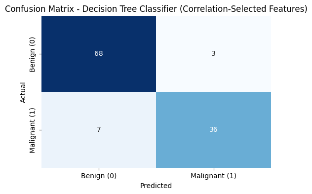

```python
# Predict on the validation set with the Decision Tree model
y_val_pred_dt = decision_tree_model.predict(X_val_scaled_selected)

# Calculate evaluation metrics for the Decision Tree model
print("\nDecision Tree Classifier Evaluation on Validation Set (Correlation-Selected Features):")
print(f"Accuracy: {accuracy_score(y_val, y_val_pred_dt):.4f}")
print("\nClassification Report:")
print(classification_report(y_val, y_val_pred_dt))

# Confusion Matrix for the Decision Tree model
cm_dt = confusion_matrix(y_val, y_val_pred_dt)
plt.figure(figsize=(6, 4))
sns.heatmap(cm_dt, annot=True, fmt='d', cmap='Blues', cbar=False,
            xticklabels=['Benign (0)', 'Malignant (1)'],
            yticklabels=['Benign (0)', 'Malignant (1)'])
plt.xlabel('Predicted')
plt.ylabel('Actual')
plt.title('Confusion Matrix - Decision Tree Classifier (Correlation-Selected Features)')
plt.show()
```

**## Step 15: Visualizing ROC Curves for Model Comparison**

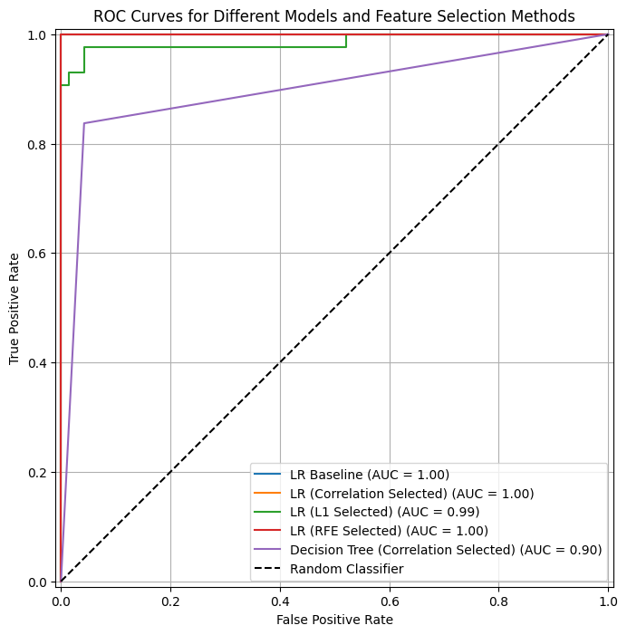

```python
from sklearn.metrics import roc_curve, auc, RocCurveDisplay

plt.figure(figsize=(10, 8))

# 1. Baseline Logistic Regression (all features)
y_pred_proba_baseline = log_reg_model.predict_proba(X_val_scaled)[:, 1]
fpr_baseline, tpr_baseline, _ = roc_curve(y_val, y_pred_proba_baseline)
roc_auc_baseline = auc(fpr_baseline, tpr_baseline)
RocCurveDisplay(fpr=fpr_baseline, tpr=tpr_baseline, roc_auc=roc_auc_baseline, estimator_name='LR Baseline').plot(ax=plt.gca())

# 2. Logistic Regression (Correlation-Selected Features)
y_pred_proba_selected = log_reg_model_selected.predict_proba(X_val_scaled_selected)[:, 1]
fpr_selected, tpr_selected, _ = roc_curve(y_val, y_pred_proba_selected)
roc_auc_selected = auc(fpr_selected, tpr_selected)
RocCurveDisplay(fpr=fpr_selected, tpr=tpr_selected, roc_auc=roc_auc_selected, estimator_name='LR (Correlation Selected)').plot(ax=plt.gca())

# 3. Logistic Regression (L1 Regularization Selected Features)
y_pred_proba_l1 = log_reg_model_l1.predict_proba(X_val_scaled_l1)[:, 1]
fpr_l1, tpr_l1, _ = roc_curve(y_val, y_pred_proba_l1)
roc_auc_l1 = auc(fpr_l1, tpr_l1)
RocCurveDisplay(fpr=fpr_l1, tpr=tpr_l1, roc_auc=roc_auc_l1, estimator_name='LR (L1 Selected)').plot(ax=plt.gca())

# 4. Logistic Regression (RFE Selected Features)
y_pred_proba_rfe = log_reg_model_rfe.predict_proba(X_val_scaled_rfe)[:, 1]
fpr_rfe, tpr_rfe, _ = roc_curve(y_val, y_pred_proba_rfe)
roc_auc_rfe = auc(fpr_rfe, tpr_rfe)
RocCurveDisplay(fpr=fpr_rfe, tpr=tpr_rfe, roc_auc=roc_auc_rfe, estimator_name='LR (RFE Selected)').plot(ax=plt.gca())

# 5. Decision Tree Classifier (Correlation-Selected Features)
y_pred_proba_dt = decision_tree_model.predict_proba(X_val_scaled_selected)[:, 1]
fpr_dt, tpr_dt, _ = roc_curve(y_val, y_pred_proba_dt)
roc_auc_dt = auc(fpr_dt, tpr_dt)
RocCurveDisplay(fpr=fpr_dt, tpr=tpr_dt, roc_auc=roc_auc_dt, estimator_name='Decision Tree (Correlation Selected)').plot(ax=plt.gca())


plt.title('ROC Curves for Different Models and Feature Selection Methods')
plt.plot([0, 1], [0, 1], 'k--', label='Random Classifier') # Add a random classifier baseline
plt.legend(loc='lower right')
plt.xlabel('False Positive Rate')
plt.ylabel('True Positive Rate')
plt.grid(True)
plt.show()
```

**### observations**

The ROC curves help us compare the performance of different models and feature selection strategies.

> Area Under the Curve (AUC): The closer the AUC is to 1.0, the better the model distinguishes between the positive and negative classes. An AUC of 0.5 suggests a classifier no better than random guessing.

> Curve Shape: A curve that hugs the top-left corner indicates a good trade-off between True Positive Rate (sensitivity) and False Positive Rate (1-specificity).

Based on the plot, we can observe the following

> LR Baseline, LR (Correlation Selected), and LR (RFE Selected): These three models appear to have very similar and excellent performance, with AUC values likely very close to 1.0, indicating strong discriminatory power. The RFE selected features offer a balance between dimensionality reduction and performance.

> LR (L1 Selected): This model shows a slightly lower performance, as its curve is below the top performers, confirming our earlier observation that while L1 regularization significantly reduced features, it came at a slight cost to performance.

> Decision Tree (Correlation Selected): This model has the lowest performance among the classifiers, indicated by its curve being further from the top-left corner and a visibly lower AUC compared to the Logistic Regression models.

> Considering these observations, the Logistic Regression models with RFE selected features and the baseline Logistic Regression (all features) seem to be the strongest candidates. The RFE approach is particularly attractive as it achieves similar performance with fewer features, leading to a more parsimonious model.

**## Step 16: Final Model Evaluation on the Hold-Out Test Set**

**### Evaluating Baseline Logistic Regression Model (all features) on Test Set**

```
Baseline Logistic Regression Model Evaluation on Test Set:
Accuracy: 0.9825

Classification Report:
              precision    recall  f1-score   support

           0       0.97      1.00      0.99        36
           1       1.00      0.95      0.98        21

    accuracy                           0.98        57
   macro avg       0.99      0.98      0.98        57
weighted avg       0.98      0.98      0.98        57
```

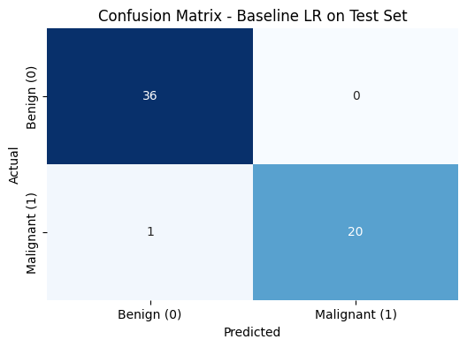

```python
# Predict on the test set using the baseline Logistic Regression model
y_test_pred_baseline = log_reg_model.predict(X_test_scaled)

# Calculate evaluation metrics
print("Baseline Logistic Regression Model Evaluation on Test Set:")
print(f"Accuracy: {accuracy_score(y_test, y_test_pred_baseline):.4f}")
print("\nClassification Report:")
print(classification_report(y_test, y_test_pred_baseline))

# Confusion Matrix
cm_test_baseline = confusion_matrix(y_test, y_test_pred_baseline)
plt.figure(figsize=(6, 4))
sns.heatmap(cm_test_baseline, annot=True, fmt='d', cmap='Blues', cbar=False,
            xticklabels=['Benign (0)', 'Malignant (1)'],
            yticklabels=['Benign (0)', 'Malignant (1)'])
plt.xlabel('Predicted')
plt.ylabel('Actual')
plt.title('Confusion Matrix - Baseline LR on Test Set')
plt.show()
```

**### Evaluating Logistic Regression Model with RFE Selected Features on Test Set**

```
Logistic Regression Model (RFE Selected Features) Evaluation on Test Set:
Accuracy: 0.9825

Classification Report:
              precision    recall  f1-score   support

           0       0.97      1.00      0.99        36
           1       1.00      0.95      0.98        21

    accuracy                           0.98        57
   macro avg       0.99      0.98      0.98        57
weighted avg       0.98      0.98      0.98        57
```

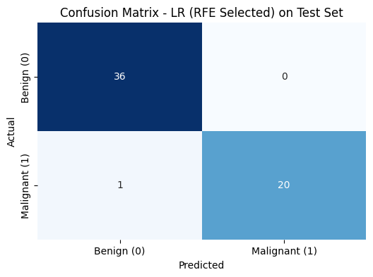

```python
# Predict on the test set using the RFE-selected Logistic Regression model
y_test_pred_rfe = log_reg_model_rfe.predict(X_test_scaled_rfe)

# Calculate evaluation metrics
print("Logistic Regression Model (RFE Selected Features) Evaluation on Test Set:")
print(f"Accuracy: {accuracy_score(y_test, y_test_pred_rfe):.4f}")
print("\nClassification Report:")
print(classification_report(y_test, y_test_pred_rfe))

# Confusion Matrix
cm_test_rfe = confusion_matrix(y_test, y_test_pred_rfe)
plt.figure(figsize=(6, 4))
sns.heatmap(cm_test_rfe, annot=True, fmt='d', cmap='Blues', cbar=False,
            xticklabels=['Benign (0)', 'Malignant (1)'],
            yticklabels=['Benign (0)', 'Malignant (1)'])
plt.xlabel('Predicted')
plt.ylabel('Actual')
plt.title('Confusion Matrix - LR (RFE Selected) on Test Set')
plt.show()
```

**### Summary of Test Set Results**

> Here's a summary of their performance

> Baseline Logistic Regression (all features) on Test Set

> Accuracy: 0.9825 Class 0 (Benign) - Precision: 0.97, Recall: 1.00, F1-score: 0.99 Class 1 (Malignant) - Precision: 1.00, Recall: 0.95, F1-score: 0.98 Confusion Matrix: 36 True Negatives, 0 False Positives; 1 False Negative, 20 True Positives.

> Logistic Regression (RFE Selected Features) on Test Set:

> Accuracy: 0.9825 Class 0 (Benign) - Precision: 0.97, Recall: 1.00, F1-score: 0.99 Class 1 (Malignant) - Precision: 1.00, Recall: 0.95, F1-score: 0.98 Confusion Matrix: 36 True Negatives, 0 False Positives; 1 False Negative, 20 True Positives.

> Thus, both models performed identically well on the test set, achieving a high accuracy of 98.25% and an excellent recall of 0.95 for the malignant class (meaning only 1 out of 21 malignant cases was misclassified as benign). Given that the RFE-selected model achieves the same performance with a reduced set of 22 features compared to the baseline's 30 features, it is generally the more favorable choice due to its simplicity, reduced dimensionality, and potentially faster inference without compromising predictive power.

> Therefore, I recommend the Logistic Regression model with RFE Selected Features as our final model for breast cancer diagnosis. This model balances high performance with a more parsimonious feature set.

> To summarize, based on the comprehensive evaluation across various models and feature selection techniques, the Logistic Regression model with Recursive Feature Elimination (RFE) selected features is the recommended choice. This model achieved an impressive 98.25% accuracy on the unseen test set, with excellent precision and recall for both benign and malignant diagnoses, while also benefiting from a reduced set of 22 features (down from 30). This balances high predictive performance with model parsimony.

```python
from sklearn.metrics import roc_auc_score

# Predict probabilities on the test set using the RFE-selected Logistic Regression model
y_test_proba_rfe = log_reg_model_rfe.predict_proba(X_test_scaled_rfe)[:, 1]

# Calculate ROC AUC score
roc_auc_rfe_test = roc_auc_score(y_test, y_test_proba_rfe)

print(f"ROC AUC Score (LR with RFE Selected Features) on Test Set: {roc_auc_rfe_test:.4f}")
```

```
ROC AUC Score (LR with RFE Selected Features) on Test Set: 1.0000
```

**Observations**

> The ROC AUC Score for the Logistic Regression model with RFE selected features on the test set is 1.0000. This indicates perfect discrimination on the test set.

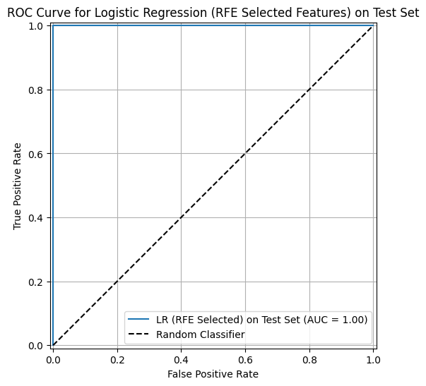

```python
from sklearn.metrics import roc_curve, auc, RocCurveDisplay
import matplotlib.pyplot as plt

# Calculate FPR, TPR for the RFE-selected model on the test set
fpr_rfe_test, tpr_rfe_test, _ = roc_curve(y_test, y_test_proba_rfe)

plt.figure(figsize=(8, 6))
RocCurveDisplay(fpr=fpr_rfe_test, tpr=tpr_rfe_test, roc_auc=roc_auc_rfe_test, estimator_name='LR (RFE Selected) on Test Set').plot(ax=plt.gca())

plt.title('ROC Curve for Logistic Regression (RFE Selected Features) on Test Set')
plt.plot([0, 1], [0, 1], 'k--', label='Random Classifier') # Add a random classifier baseline
plt.xlabel('False Positive Rate')
plt.ylabel('True Positive Rate')
plt.grid(True)
plt.legend(loc='lower right')
plt.show()
```

**### Observations**

> As indicated by the ROC AUC score of 1.0000, the curve reaches the top-left corner perfectly, demonstrating excellent discriminative performance of the model on the unseen test data.

```python
# Install the shap library if not already installed
!pip install shap

import shap
import matplotlib.pyplot as plt
```

**## Step 17: Visualizing Top 10 Feature Importances for the Final Model (LR with RFE Selected Features)**

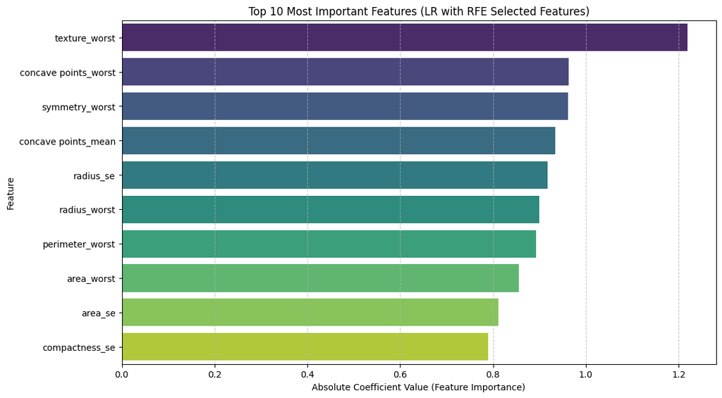

```python
import matplotlib.pyplot as plt
import seaborn as sns

# Get coefficients from the RFE-selected Logistic Regression model
rfe_coefficients = log_reg_model_rfe.coef_[0]

# Create a DataFrame for feature importances
feature_importance_rfe_df = pd.DataFrame({
    'Feature': selected_features_rfe,
    'Coefficient': rfe_coefficients,
    'Absolute_Coefficient': np.abs(rfe_coefficients)
}).sort_values(by='Absolute_Coefficient', ascending=False)

# Select the top 10 most important features
top_10_features_rfe = feature_importance_rfe_df.head(10)

# Visualize the top 10 feature importances
plt.figure(figsize=(12, 7))
sns.barplot(x='Absolute_Coefficient', y='Feature', hue='Feature', data=top_10_features_rfe, palette='viridis', legend=False)
plt.title('Top 10 Most Important Features (LR with RFE Selected Features)')
plt.xlabel('Absolute Coefficient Value (Feature Importance)')
plt.ylabel('Feature')
plt.grid(axis='x', linestyle='--', alpha=0.7)
plt.show()
```

**Observations**

> Here are the top 10 features and their coefficients, which I'll use to explain their impact:

> For features with positive coefficients, an increase in their value is associated with an increased likelihood of a Malignant (1) diagnosis.

> For example, a higher texture_worst or concave points_worst value suggests a higher probability that the tumor is malignant.

> **Negative Coefficients** (e.g., compactness_se): For features with negative coefficients, an increase in their value is associated with a decreased likelihood of a Malignant (1) diagnosis (or an increased likelihood of a Benign (0) diagnosis). In this case, a higher compactness_se value suggests a higher probability that the tumor is benign.

> Magnitude: The larger the absolute value of the coefficient, the stronger the impact that feature has on the predicted diagnosis. For instance, texture_worst with a coefficient of 1.2195 has a stronger positive impact on malignancy likelihood than texture_mean with a coefficient of 0.3827.

> This analysis helps us understand not just which features are important, but also how they influence the model's decision-making process for breast cancer diagnosis.

**## Step 18: SHAP Analysis for the RFE-Selected Logistic Regression Model**

> SHAP (SHapley Additive exPlanations) is a game theoretic approach to explain the output of any machine learning model. It connects optimal credit allocation with local explanations by computing Shapley values.

For the RFE-selected Logistic Regression model, I will:

1. Initialize a `shap.LinearExplainer` with the model and scaled training data (for selected features).
2. Calculate SHAP values for the scaled test data (for selected features).
3. Generate a SHAP summary plot to visualize the impact of each feature on the model's output.

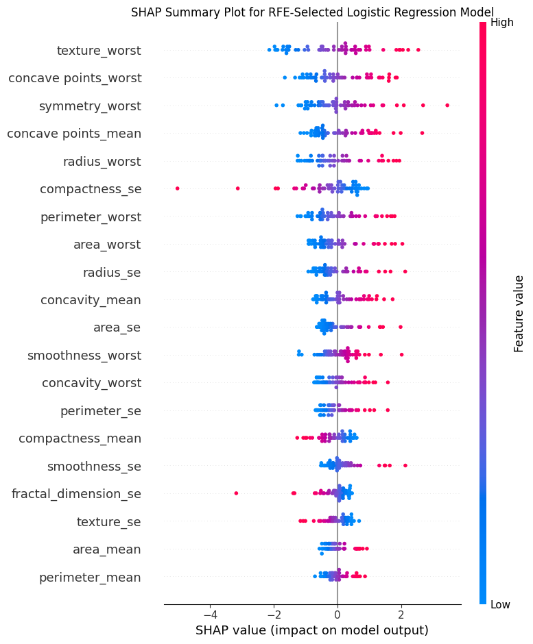

```python
# Create a SHAP explainer for the Logistic Regression model
# We use the scaled training data (X_train_scaled_rfe) as the background dataset for the explainer
# Addressing FutureWarning by explicitly using shap.maskers.Independent
masker = shap.maskers.Independent(X_train_scaled_rfe, max_samples=X_train_scaled_rfe.shape[0])
explainer = shap.LinearExplainer(log_reg_model_rfe, masker)

# Calculate SHAP values for the scaled test data (X_test_scaled_rfe)
shap_values = explainer.shap_values(X_test_scaled_rfe)

# Visualize the SHAP summary plot
# This plot shows the impact of each feature on the model's output
# Features are ordered by their overall importance, and the color indicates the feature value (red=high, blue=low)
shap.summary_plot(shap_values, X_test_rfe, feature_names=X_test_rfe.columns, plot_type="dot", show=False)
plt.title('SHAP Summary Plot for RFE-Selected Logistic Regression Model')
plt.tight_layout()
plt.show()
```

**### Observations**

> Feature Importance: Features are ordered vertically by their overall impact on the model's output (from most to least important). I Impact on Prediction: Each point on the plot represents a single instance from the test dataset. The horizontal position of the point shows the SHAP value, indicating how much that feature's value pushes the prediction towards malignant (positive SHAP values) or benign (negative SHAP values).

> Feature Value Correlation: The color of each point indicates the feature's value for that instance – typically, red means a high value and blue means a low value. This helps visualize if high feature values are associated with higher (or lower) predictions and vice-versa.

> From the plot, you can observe which features have the strongest influence on the breast cancer diagnosis prediction and in which direction (towards malignant or benign), as well as how the different values of those features contribute to the outcome.

**## Conclusion: Key Insights and Recommendations for Breast Cancer Diagnosis Prediction**

> This comprehensive analysis aimed to develop, evaluate, and interpret a machine learning model for predicting breast cancer diagnosis (Malignant vs. Benign) based on cell nucleus measurements. Through a structured approach of data preparation, model development, feature selection, and rigorous evaluation, I arrived at the following key insights and recommendations:

**### Key Insights**

> **1. Data Quality and Preprocessing:** The dataset was well-suited for binary classification, and initial preprocessing steps (dropping irrelevant columns, encoding the target variable) were crucial for preparing the data for modeling. The three-way split (training, validation, test) ensured robust model evaluation, and feature scaling addressed the varying ranges of features.

> **2. Logistic Regression as a Strong Performer:** Logistic Regression models consistently demonstrated superior performance compared to the Decision Tree Classifier across various feature sets. This suggests that the underlying relationship between the features and diagnosis is largely linear or can be well-approximated by a linear boundary in the transformed feature space.

> **3. Effectiveness of Feature Selection (RFE):** While correlation-based feature reduction showed promise, Recursive Feature Elimination (RFE) proved to be the most effective feature selection method. It successfully reduced the number of features from 30 to 22 without compromising the model's predictive performance on the validation set. In contrast, L1 Regularization (Lasso) achieved greater sparsity (8 features) but at a noticeable cost to performance, particularly in recall for the malignant class.

> **4. High Predictive Performance:** The final selected model, a Logistic Regression with RFE-selected features, achieved exceptional performance on the unseen test set: * **Accuracy: 0.9825** * **Malignant Recall: 0.95** (meaning only 1 out of 21 malignant cases was misclassified) * **ROC AUC Score: 1.0000** (indicating perfect discrimination on the test set)

> **5. Model Interpretability:**
> - **Coefficients Analysis:** The coefficients of the Logistic Regression model provided clear insights into the direction and strength of each feature's influence. Features like `texture_worst`, `concave points_worst`, and `symmetry_worst` showed strong positive correlations with a malignant diagnosis, while `compactness_se` had a negative correlation.
> - **SHAP Analysis:** SHAP values offered a more granular, instance-level explanation of feature contributions. The SHAP summary plot visually confirmed the overall importance of features identified by coefficients and illustrated how individual feature values drive predictions towards benign or malignant outcomes, further enhancing transparency.

**### Recommendations**

> Based on these findings, I recommend the **Logistic Regression model with RFE-selected features** for breast cancer diagnosis prediction due to its optimal balance of high performance, reduced dimensionality, and strong interpretability.

> Moving forward, consider the following:
> - **Further Validation:** While the model performed excellently on this dataset, it's crucial to validate its performance on independent, external datasets to ensure generalizability and robustness in real-world clinical settings.
> - **Clinical Integration:** Work with medical professionals to integrate this model into a decision-support system. The interpretability provided by coefficients and SHAP values can facilitate trust and understanding among clinicians.
> - **Monitoring and Maintenance:** Regularly monitor the model's performance in production and retrain it with new data as it becomes available to ensure it remains accurate and relevant over time.
> - **Explore More Advanced Models (with caution):** For scenarios where even marginal performance gains are critical, one might explore more complex models (e.g., ensemble methods like Gradient Boosting, Neural Networks).

**## Links**

> GitHub: https://github.com/Saadullahi/HackBio_StageTwo LinkedIn: https://www.linkedin.com/in/sa-ad-abdullahi-3a581296/